# index

## Table of Contents:

- Introduction
- Data Collection and Imports
- Data Clean Up
- Data Exploration
- Outlier Removal
- Data Exploration without Outliers
- Predicition and Machine Learning using Regression
- Conclusion

## Introduction: Predicting How Many Followers Twitch Streamers Gained Over a Year

Sean Fitzgerald and David Dayton

CMSC320

**Introduction**

Twitch.tv is a popular live-streaming platform owned by Amazon that was originally made for gamers to live-stream themselves playing video games. In recent years it has expanded its audience to more than gamers with the addition of streaming categories such as "Just Chatting" and "Talk Shows & Podcasts." This data set contains analytics for Twitch's top 1000 channels taken over a year. The data used is available [here](https://www.kaggle.com/datasets/thedevastator/twitch-streamers-comparing-top-streamers-across?select=Twitch_data_39_2022.csv). In this tutorial, we will go through the steps of: Data Collection, Data Clean Up, Data Exploration, Outlier Removal, and Predicition and Machine Learning using Regression! Our goal is to attempt to predict total Followers Gained over a year using the columns in the dataset.

## Data Collection and imports

We are pulling the data from a CVS file downloaded from the link above.

```python
import pandas as pd
import matplotlib.pyplot as plt
import numpy as np
import seaborn as sns
from sklearn.linear_model import Ridge
from sklearn.linear_model import LinearRegression
from sklearn.ensemble import RandomForestRegressor
from sklearn import linear_model
import statsmodels.api as sm
from sklearn.model_selection import train_test_split
from sklearn.model_selection import GridSearchCV
from sklearn.model_selection import cross_val_score
from sklearn.metrics import mean_squared_error
from google.colab import drive
df = pd.read_csv("/content/drive/MyDrive/twitchdata-update.csv")
```

```python
df
```

|  | Channel | Watch time(Minutes) | Stream time(minutes) | Peak viewers | Average viewers | Followers | Followers gained | Views gained | Partnered | Mature | Language |
| --- | --- | --- | --- | --- | --- | --- | --- | --- | --- | --- | --- |
| 0 | xQcOW | 6196161750 | 215250 | 222720 | 27716 | 3246298 | 1734810 | 93036735 | True | False | English |
| 1 | summit1g | 6091677300 | 211845 | 310998 | 25610 | 5310163 | 1370184 | 89705964 | True | False | English |
| 2 | Gaules | 5644590915 | 515280 | 387315 | 10976 | 1767635 | 1023779 | 102611607 | True | True | Portuguese |
| 3 | ESL_CSGO | 3970318140 | 517740 | 300575 | 7714 | 3944850 | 703986 | 106546942 | True | False | English |
| 4 | Tfue | 3671000070 | 123660 | 285644 | 29602 | 8938903 | 2068424 | 78998587 | True | False | English |
| ... | ... | ... | ... | ... | ... | ... | ... | ... | ... | ... | ... |
| 995 | LITkillah | 122524635 | 13560 | 21359 | 9104 | 601927 | 562691 | 2162107 | True | False | Spanish |
| 996 | 빅헤드 (bighead033) | 122523705 | 153000 | 3940 | 793 | 213212 | 52289 | 4399897 | True | False | Korean |
| 997 | 마스카 (newmasca) | 122452320 | 217410 | 6431 | 567 | 109068 | -4942 | 3417970 | True | False | Korean |
| 998 | AndyMilonakis | 122311065 | 104745 | 10543 | 1153 | 547446 | 109111 | 3926918 | True | False | English |
| 999 | Remx | 122192850 | 99180 | 13788 | 1205 | 178553 | 59432 | 2049420 | True | False | French |

1000 rows × 11 columns

## Data Clean Up

The column names have inconsistent capitalizing and naming conventions. We are changing them to help with structure and organization. We are also dropping the "Partnered," "Mature," and "Langauge" columns as they are not relevant to what we are looking at, and in the "Partnered" case, the majority was "yes," which would create artificial outliers in the dataset. Then we want to make sure we don't have any missing values in the dataset.

```python
# Rename colums to make typing and readibility easier
df = df.rename(columns = {"Watch time(Minutes)": "Watch_Time", "Stream time(minutes)": "Stream_Time",
                          "Followers gained": "Followers_Gained", "Peak viewers": "Peak_Viewers",
                          "Average viewers": "Average_Viewers", "Views gained": "Views_Gained"})
# Drop Partnered, Mature, and Language Columns as they are not relevent to what we are looking for
df = df.drop(columns = {"Partnered", "Mature", "Language"})
# Display the new dataset
df
```

|  | Channel | Watch_Time | Stream_Time | Peak_Viewers | Average_Viewers | Followers | Followers_Gained | Views_Gained |
| --- | --- | --- | --- | --- | --- | --- | --- | --- |
| 0 | xQcOW | 6196161750 | 215250 | 222720 | 27716 | 3246298 | 1734810 | 93036735 |
| 1 | summit1g | 6091677300 | 211845 | 310998 | 25610 | 5310163 | 1370184 | 89705964 |
| 2 | Gaules | 5644590915 | 515280 | 387315 | 10976 | 1767635 | 1023779 | 102611607 |
| 3 | ESL_CSGO | 3970318140 | 517740 | 300575 | 7714 | 3944850 | 703986 | 106546942 |
| 4 | Tfue | 3671000070 | 123660 | 285644 | 29602 | 8938903 | 2068424 | 78998587 |
| ... | ... | ... | ... | ... | ... | ... | ... | ... |
| 995 | LITkillah | 122524635 | 13560 | 21359 | 9104 | 601927 | 562691 | 2162107 |
| 996 | 빅헤드 (bighead033) | 122523705 | 153000 | 3940 | 793 | 213212 | 52289 | 4399897 |
| 997 | 마스카 (newmasca) | 122452320 | 217410 | 6431 | 567 | 109068 | -4942 | 3417970 |
| 998 | AndyMilonakis | 122311065 | 104745 | 10543 | 1153 | 547446 | 109111 | 3926918 |
| 999 | Remx | 122192850 | 99180 | 13788 | 1205 | 178553 | 59432 | 2049420 |

1000 rows × 8 columns

```python
# Iterate through each row, eaching for missing values
# There are 1000 rows in the dataframe, and we will be counting the entires
# If there are 1000s printed in every line below than there are no missing values

for each in df.columns:
  print(each + ": " + str(df[pd.notnull(df[each])][each].count()))
```

```
Channel: 1000
Watch_Time: 1000
Stream_Time: 1000
Peak_Viewers: 1000
Average_Viewers: 1000
Followers: 1000
Followers_Gained: 1000
Views_Gained: 1000
```

## Data Exploration

This section will explore the relationships between the columns in the dataset and our target variable, Followers Gained. We will start by making scatterplots with a best-fitted line and analyze the trends and problems it might show.

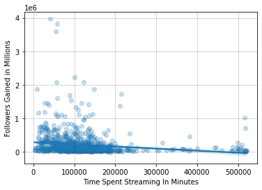

```python
# Make a clone data base to add change for data exploration
df_clone = df.copy()

# Below is a Seaborn plor Average_Viewers over Stream_time
graph = sns.regplot(x = "Stream_Time", y = "Followers_Gained", data = df_clone, scatter_kws = {"alpha" : 0.25});
graph.set(xlabel = "Time Spent Streaming In Minutes", ylabel = "Followers Gained in Millions")
plt.grid(color = "black", alpha = 0.2)
```

Above is a scatterplot of Followers Gained over Stream Time. We can see that there are clear outliers, in addition to there being a negative correlation between the columns.

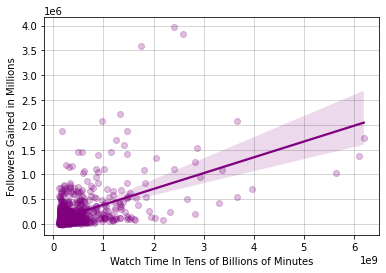

```python
# The Seaborn plot below is looking at the realtionship of Followers_Gained over Watch_Time
graph = sns.regplot(x = "Watch_Time", y = "Followers_Gained", data = df_clone, color = "purple", scatter_kws = {"alpha" : 0.25});
graph.set(xlabel = "Watch Time In Tens of Billions of Minutes", ylabel = "Followers Gained in Millions")
plt.grid(color = "black", alpha = 0.2)
```

The next plot is of Followers Gained over Watch Time. It is once again clear this dataset has an issue with outliers. The data seems to clump towards the lower values of both Watch Time and Followers Gained.

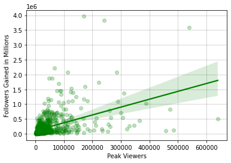

```python
# Plot showing how follower growth changes with peak viewership
graph = sns.regplot(x = "Peak_Viewers", y = "Followers_Gained", data=df_clone, color="green", scatter_kws = {"alpha" : 0.25})
graph.set(xlabel = "Peak Viewers", ylabel = "Followers Gained in Millions")
plt.grid(color = "black", alpha = 0.2)
```

This graph plots Followers Gained over Peak Viewers, and there is a clear positive correlation.

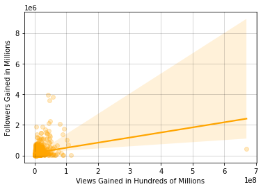

```python
# Plot Followers Gained over viewers gained
graph = sns.regplot(x = "Views_Gained", y = "Followers_Gained", data=df_clone, color="Orange", scatter_kws = {"alpha" : 0.25})
graph.set(xlabel = "Views Gained in Hundreds of Millions", ylabel = "Followers Gained in Millions")
plt.grid(color = "black", alpha = 0.2)
```

Followers Gained over total Views. This graph has the biggest outlier we have seen so far.

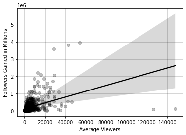

```python
# Plot Followers Gained over viewers gained
graph = sns.regplot(x = "Average_Viewers", y = "Followers_Gained", data=df_clone, color="Black", scatter_kws =  {"alpha" : 0.25})
graph.set(xlabel = "Average Viewers", ylabel = "Followers Gained in Millions")
plt.grid(color = "black", alpha = 0.2)
```

The last plot is Followers Gained over Average Viewers. This graph has a positive coorelation but huge outliers. We have wittnessed that all of the graphs have extream outliers that need to be taken care of. With the current data, prediciting Followers Gained is going to be extreamly innaccurate.

## Outlier Removal

It is clear from the graphs above that many outliers are making the data unreadable, and hard to predict. We are going to rescope our data frame but cutting out the large outliers and looking at where the data is most populated.

We are achieving this by filtering the database with cutoffs determined by the graphs above. Our goal is to have the clustered bulk of the data shown in the graphs above be the main representation of the predictions.

This resulted in a reduction of 335 rows. This number is high when compared to the starting 1000 rows, but it is necessary as much of the data set are outliers.

```python
# From the first plot, remove outlier Average Viewers and cut down on time spent streaming
df = df[df.Average_Viewers < 7000]
df = df[df.Stream_Time < 250000]

# From the scond graph, cut down Watch time and Followers Gained
df = df[df.Watch_Time < 600000000]
df = df[df.Followers_Gained < 450000]

# From the third graph cut downb Peak Viewers
df = df[df.Peak_Viewers < 60000]

# From the fourth graph cut off Views gained
df = df[df.Views_Gained < 20000000]

df
```

|  | Channel | Watch_Time | Stream_Time | Peak_Viewers | Average_Viewers | Followers | Followers_Gained | Views_Gained |
| --- | --- | --- | --- | --- | --- | --- | --- | --- |
| 160 | MYM_ALKAPONE | 599850495 | 97830 | 26221 | 5948 | 770535 | 153803 | 7831334 |
| 161 | 김진우 (jinu6734) | 597275955 | 121545 | 12810 | 4710 | 274875 | 90213 | 9977487 |
| 162 | imaqtpie | 596368095 | 167190 | 26087 | 3478 | 2652018 | 50312 | 13182700 |
| 164 | C_a_k_e | 588662010 | 129660 | 17317 | 4403 | 302633 | 45957 | 18161823 |
| 166 | RatedEpicz | 582401145 | 175920 | 11860 | 3336 | 134757 | 74221 | 7251200 |
| ... | ... | ... | ... | ... | ... | ... | ... | ... |
| 993 | LAGTVMaximusBlack | 123125340 | 161535 | 7138 | 725 | 256353 | 13251 | 2310313 |
| 996 | 빅헤드 (bighead033) | 122523705 | 153000 | 3940 | 793 | 213212 | 52289 | 4399897 |
| 997 | 마스카 (newmasca) | 122452320 | 217410 | 6431 | 567 | 109068 | -4942 | 3417970 |
| 998 | AndyMilonakis | 122311065 | 104745 | 10543 | 1153 | 547446 | 109111 | 3926918 |
| 999 | Remx | 122192850 | 99180 | 13788 | 1205 | 178553 | 59432 | 2049420 |

665 rows × 8 columns

## Data Exporation without Outliers

Now we will recreate the graphs above with the reduced dataset. This will show the clear distinction between the original and altered datasets and show how useful outlier removal is.

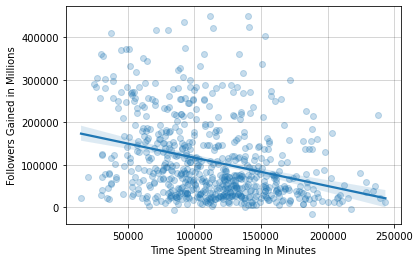

```python
# Below is a Seaborn plor Average_Viewers over Stream_time
graph = sns.regplot(x = "Stream_Time", y = "Followers_Gained", data = df, scatter_kws = {"alpha" : 0.25});
graph.set(xlabel = "Time Spent Streaming In Minutes", ylabel = "Followers Gained in Millions")
plt.grid(color = "black", alpha = 0.2)
```

Above is a recreation of the first plot with the altered data set. We can immediately see the main part of the data is much more clear and more informative. There is still a negative correlation, and there is still a wide spread of data points.

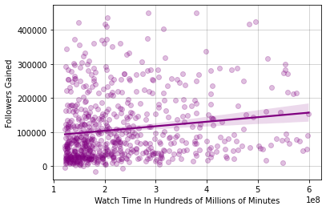

```python
# The Seaborn plot below is looking at the realtionship of Followers_Gained over Watch_Time
graph = sns.regplot(x = "Watch_Time", y = "Followers_Gained", data = df, color = "purple", scatter_kws = {"alpha" : 0.25});
graph.set(xlabel = "Watch Time In Hundreds of Millions of Minutes", ylabel = "Followers Gained")
plt.grid(color = "black", alpha = 0.2)
```

This graph shows a stark difference in correlation. The original graph had a steep positive correlation, and this graph, while still positive, shows the correlation is much less.

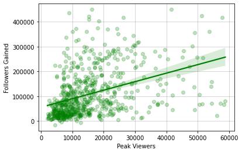

```python
# Plot showing how follower growth changes with peak viewership
graph = sns.regplot(x = "Peak_Viewers", y = "Followers_Gained", data=df, color="green", scatter_kws = {"alpha" : 0.25})
graph.set(xlabel = "Peak Viewers", ylabel = "Followers Gained")
plt.grid(color = "black", alpha = 0.2)
```

Followers Gained over Peak Viewers kept a strong positive correlation, although we still can see the data clumping on the lower end values of the graph.

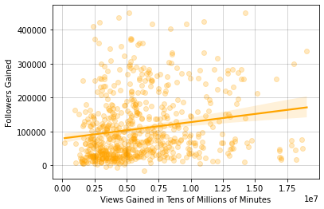

```python
# Plot Followers Gained over viewers gained
graph = sns.regplot(x = "Views_Gained", y = "Followers_Gained", data=df, color="Orange", scatter_kws = {"alpha" : 0.25})
graph.set(xlabel = "Views Gained in Tens of Millions of Minutes", ylabel = "Followers Gained")
plt.grid(color = "black", alpha = 0.2)
```

The plot above also now has a lower positive correlation than the previous graph. The data now is more evenly spread out.

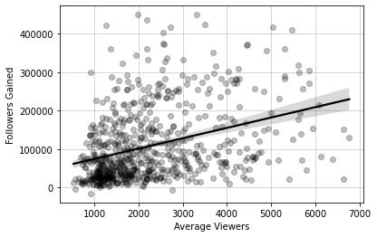

```python
# Plot Followers Gained over viewers gained
graph = sns.regplot(x = "Average_Viewers", y = "Followers_Gained", data=df, color="Black", scatter_kws =  {"alpha" : 0.25})
graph.set(xlabel = "Average Viewers", ylabel = "Followers Gained")
plt.grid(color = "black", alpha = 0.2)
```

The Followers Gained over Average Followers graph continues the trend of lower positive correlation and better data distribution.

Through all these graphs, it is clear removing the outliers improved the variance, clarity, and usefulness of the data.

The next few graphs are distribution plots of each of the columns we will be using to predict Followers Gained and Followers Gained itself. This information will let us look more specifically at where each variable is clumping.

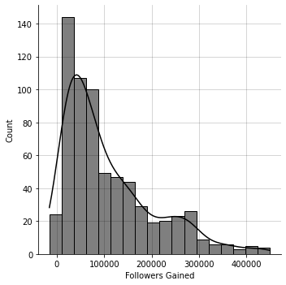

```python
graph = sns.displot(x= "Followers_Gained", data=df, kde = True, color = "black")
graph.set(xlabel = "Followers Gained", ylabel = "Count")
plt.grid(color = "black", alpha = 0.2)
```

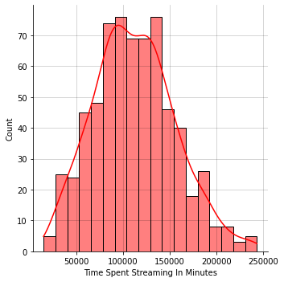

```python
graph = sns.displot(x= "Stream_Time", data=df, kde = True, color = "Red")
graph.set(xlabel = "Time Spent Streaming In Minutes", ylabel = "Count")
plt.grid(color = "black", alpha = 0.2)
```

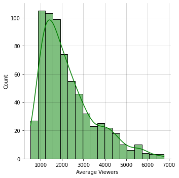

```python
graph = sns.displot(x= "Average_Viewers", data=df, kde = True, color = "Green")
graph.set(xlabel = "Average Viewers", ylabel = "Count")
plt.grid(color = "black", alpha = 0.2)
```

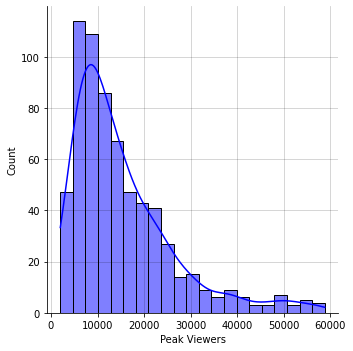

```python
graph = sns.displot(x= "Peak_Viewers", data=df, kde = True, color = "Blue")
graph.set(xlabel = "Peak Viewers", ylabel = "Count")
plt.grid(color = "black", alpha = 0.2)
```

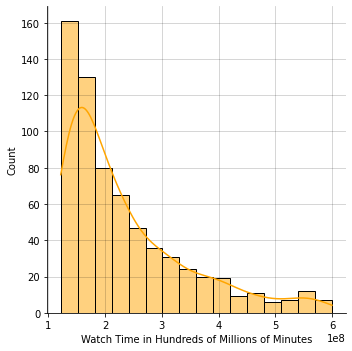

```python
graph = sns.displot(x= "Watch_Time", data=df, kde = True, color = "Orange")
graph.set(xlabel = "Watch Time in Hundreds of Millions of Minutes", ylabel = "Count")
plt.grid(color = "black", alpha = 0.2)
```

## Predicition and Machine Learning using Regression!

The first thing we are going to do is look for features worth dropping due to a high P-Value or multicollinearity that may exist. A high P-Value indicates that the feature is not strong enough to suggest an effect exists in the population. Multicollinearity is when correlated features are correlated to each other. This is an issue because some regression models, such as linear, will perform worse when having to deal with multicollinearity.

```python
# seperate the independent and dependent variables
X = df.drop(["Channel", "Followers_Gained"], axis = "columns")
y = df["Followers_Gained"]

# To start we are going to use Ordinary Least Squares (OLS) to help us determine
# if we have multicollinearity which may hurt our regression results.
model = sm.OLS(y, X)
fitModel = model.fit()
print(fitModel.summary())
```

```
                                 OLS Regression Results
=======================================================================================
Dep. Variable:       Followers_Gained   R-squared (uncentered):                   0.690
Model:                            OLS   Adj. R-squared (uncentered):              0.687
Method:                 Least Squares   F-statistic:                              244.6
Date:                Fri, 16 Dec 2022   Prob (F-statistic):                   5.94e-164
Time:                        21:52:06   Log-Likelihood:                         -8452.0
No. Observations:                 665   AIC:                                  1.692e+04
Df Residuals:                     659   BIC:                                  1.694e+04
Df Model:                           6
Covariance Type:            nonrobust
===================================================================================
                      coef    std err          t      P>|t|      [0.025      0.975]
-----------------------------------------------------------------------------------
Watch_Time         -0.0001   4.97e-05     -2.588      0.010      -0.000    -3.1e-05
Stream_Time         0.1555      0.061      2.540      0.011       0.035       0.276
Peak_Viewers        2.1433      0.343      6.252      0.000       1.470       2.816
Average_Viewers    19.5780      3.694      5.299      0.000      12.324      26.832
Followers           0.1112      0.011     10.164      0.000       0.090       0.133
Views_Gained        0.0005      0.001      0.431      0.667      -0.002       0.003
==============================================================================
Omnibus:                       57.006   Durbin-Watson:                   2.004
Prob(Omnibus):                  0.000   Jarque-Bera (JB):              107.250
Skew:                           0.546   Prob(JB):                     5.14e-24
Kurtosis:                       4.636   Cond. No.                     3.07e+05
==============================================================================

Notes:
[1] R² is computed without centering (uncentered) since the model does not contain a constant.
[2] Standard Errors assume that the covariance matrix of the errors is correctly specified.
[3] The condition number is large, 3.07e+05. This might indicate that there are
strong multicollinearity or other numerical problems.
```

```python
# seperate the independent and dependent variables as well as drop the unwanted variables
X = df.drop(["Channel", "Followers_Gained", "Watch_Time", "Views_Gained"], axis = "columns")
y = df["Followers_Gained"]

# Create the training and testing sets where the test set is 25% of the data.
# Random state is set to allow for reproducable training and test sets.
X_train, X_test, y_train, y_test = train_test_split(X, y, test_size = 0.25, random_state = 50)
```

Now that we have decided which features we want to drop and which ones to keep. We separate our independent and dependent variables. While doing this, we can drop our unwanted features, such as Watch_Time. Next, we separated our independent and dependent sets into a training and test set using SKLearn's train_test_split. Doing this, we took 75% of the data and kept it as the training set and put the other 25% into a test set.

Next, we will move on to predicting followers gained. To do this, we will start with linear regression, as it is the simplest of the regression models. Since we removed the multicollinearity, it will likely perform better than if we did not. Unlike the next two regression algorithms, linear regression struggles to deal with many correlated independent variables.

```python
# Start with linear regression
# Linear regression has no hyperparameters to tune
linear = LinearRegression().fit(X_train, y_train)
scores_train = cross_val_score(linear, X_train, y_train, cv = 10)
scores_test = cross_val_score(linear, X_test, y_test, cv = 10)
print("Training set average 10-fold cross validation score (R Squared):", scores_train.mean())
print("Test set average 10-fold cross validation score (R Squared):", scores_test.mean())

# To use mean squared error make a prediction on the test set
y_predicted = linear.predict(X_test)
mse = mean_squared_error(y_test, y_predicted)
print("Mean Squared Error of the test set:", mse)
```

```
Training set average 10-fold cross validation score (R Squared): 0.2417396472901107
Test set average 10-fold cross validation score (R Squared): 0.15853877536592628
Mean Squared Error of the test set: 7220376279.757099
```

Linear regression is the only regression model we will be using that does not require any form of hyperparameter tuning. With that being said, we can fit our model using the training set. Then we can use SKLearn's cross_val_score to do a 10-fold cross-validation on both the training and test set. As you can see above, our model did not perform well, with about 24.2% accuracy on the training set and only 15.9% accuracy on the test set. This shows that our model is likely to overfit due to the test set performing poorly compared to the training set. Next, we will show the mean squared error for the model, but we cannot interpret that number until we can compare it to that of our other models.

With that being said, let's move on to Ridge regression, as it is a regularised regression algorithm and will deal with correlated independent variables better than linear regression will. On top of that, regularised regression algorithms tend to do a better job of not overfitting.

```python
# It is best practice when using a regularised regression to scale your independent variables.
# However, our data is all large numbers so in this case we do not need to do this.

# Create the default Ridge model
ridge = Ridge()

# Tune Hyperparameters for Ridge regression using a Grid Search Cross Validation
# Alpha is the only hyperparameter
grid = {"alpha" : [float(x) for x in np.linspace(start = 0.01, stop = 100, num = 50)]}
tuned_ridge = GridSearchCV(estimator = ridge, param_grid = grid, cv = 10, verbose = 1, n_jobs = 4)
tuned_ridge.fit(X_train, y_train)
print("Best alpha value:", tuned_ridge.best_params_)
print("Highest score (R Squared) on the training set when attempting to tune our alpha value:", tuned_ridge.best_score_)

# use cross_val_score to get the cross validation score of the test and training sets
scores_train = cross_val_score(tuned_ridge.best_estimator_, X_train, y_train, cv = 10)
scores_test = cross_val_score(tuned_ridge.best_estimator_, X_test, y_test, cv = 10)
print("Training set average 10-fold cross validation score (R Squared):", scores_train.mean())
print("Test set average 10-fold cross validation score (R Squared):", scores_test.mean())

# To use mean squared error make a prediction on the test set
y_predicted = tuned_ridge.best_estimator_.predict(X_test)
mse = mean_squared_error(y_test, y_predicted)
print("Mean Squared Error of the test set:", mse)
```

```
Fitting 10 folds for each of 50 candidates, totalling 500 fits
Best alpha value: {'alpha': 100.0}
Highest score (R Squared) on the training set when attempting to tune our alpha value: 0.24173964799695744
Training set average 10-fold cross validation score (R Squared): 0.24173964799695744
Test set average 10-fold cross validation score (R Squared): 0.15853878446208883
Mean Squared Error of the test set: 7220376279.974376
```

Ridge regression is our first model that requires hyperparameter tuning. It only has one hyperparameter to tune, called alpha. To tune it, we are going to use SKLearn's GridSearchCV. We are picking 50 evenly spaced values between 0.01 and 100.0, and GridSearchCV will do a 10-fold cross-validation on all those different alpha values to determine which one causes our model to perform the best on our training set. The default value for alpha is 1, so to test out the two extremes on the opposite sides of 1, I chose 0.01 and 100. In the end, our ridge regression model ended up performing extremely similarly to linear regression. Both of them scored 24.2% accuracy on the training set and 15.9% accuracy on the test set. Using mean squared error, the ridge regression performed worse than the linear regression getting a higher score by 0.22.

Next are also going to try out lasso regression which is another regularised regression algorithm similar to ridge regression.

```python
# Create the default lasso model
lasso = linear_model.Lasso()

# Tune Hyperparameters for Ridge regression using a Grid Search Cross Validation
# Alpha is the only hyperparameter
grid = {"alpha" : [float(x) for x in np.linspace(start = 0.01, stop = 100, num = 50)]}
tuned_lasso = GridSearchCV(estimator = lasso, param_grid = grid, cv = 10, verbose = 1, n_jobs = 4)
tuned_lasso.fit(X_train, y_train)
print("Best alpha value:", tuned_lasso.best_params_)
print("Highest score (R Squared) on the training set when attempting to tune our alpha value:", tuned_lasso.best_score_)

# use cross_val_score to get the cross validation score of the test and training sets
scores_train = cross_val_score(tuned_lasso.best_estimator_, X_train, y_train, cv = 10)
scores_test = cross_val_score(tuned_lasso.best_estimator_, X_test, y_test, cv = 10)
print("Training set average 10-fold cross validation score (R Squared):", scores_train.mean())
print("Test set average 10-fold cross validation score (R Squared):", scores_test.mean())

# To use mean squared error make a prediction on the test set
y_predicted = tuned_lasso.best_estimator_.predict(X_test)
mse = mean_squared_error(y_test, y_predicted)
print("Mean Squared Error of the test set:", mse)
```

```
Fitting 10 folds for each of 50 candidates, totalling 500 fits
Best alpha value: {'alpha': 100.0}
Highest score (R Squared) on the training set when attempting to tune our alpha value: 0.24173989227966386
Training set average 10-fold cross validation score (R Squared): 0.24173989227966386
Test set average 10-fold cross validation score (R Squared): 0.15853877784036932
Mean Squared Error of the test set: 7220377156.595185
```

Lasso regression is fairly similar to ridge regression in the sense that they are both regularised, and they both have a single hyperparameter alpha that needs to be tuned. Since lasso's alpha value also defaults to 1, we are going to use the same alpha values to test in the GridSearchCV as we did for ridge regression. Also similar to ridge regression, our lasso model scored 24.2% accuracy on the training set and 15.9% accuracy on the test set. However, where lasso differs, it is scored decently worse on mean squared error than linear and ridge regression by about 876. This means, overall, it is a less accurate model than our linear and ridge models.

Linear, Lasso, and Ridge regression all scored very similarly when using R Squared and Mean Squared Error. In hopes of finding a more accurate model, we are going to try a random forest regression algorithm.

```python
# Create the default random forest regression model
rf = RandomForestRegressor()

# Hyperparm tuning
n_estimators = [int(x) for x in np.linspace(start = 5, stop = 150, num = 10)]
max_depth = [2, 3]
min_samples_split = [2, 5]
min_samples_leaf = [1, 2]
max_features = ["auto", "log2"]
bootstrap = [True, False]

# make the dictionary
grid = {"n_estimators" : n_estimators, "max_depth" : max_depth, "min_samples_split" : min_samples_split,
        "min_samples_leaf" : min_samples_leaf, "max_features" : max_features, "bootstrap" : bootstrap}

# Tune hyperparameters using Sklearn's GridSearchCV with 4-fold cross validation.
# We are doing less folds compared to lasso and ridge regression because we have more
# hyperparameters to tune meaning it would take a significant amount of time to do 10 folds.
tuned_rf = GridSearchCV(estimator = rf, param_grid = grid, cv = 4, verbose = 1, n_jobs = 1)
tuned_rf.fit(X_train, y_train)
print("Best hyperparameter values:", tuned_rf.best_params_)
# use cross_val_score to get the cross validation score of the test and training sets
scores_train = cross_val_score(tuned_rf.best_estimator_, X_train, y_train, cv = 10)
scores_test = cross_val_score(tuned_rf.best_estimator_, X_test, y_test, cv = 10)
print("Training set average 10-fold cross validation score (R Squared):", scores_train.mean())
print("Test set average 10-fold cross validation score (R Squared):", scores_test.mean())

# To use mean squared error make a prediction on the test set
y_predicted = tuned_rf.best_estimator_.predict(X_test)
mse = mean_squared_error(y_test, y_predicted)
print("Mean Squared Error of the test set:", mse)
```

```
Fitting 4 folds for each of 320 candidates, totalling 1280 fits
Best hyperparameter values: {'bootstrap': True, 'max_depth': 3, 'max_features': 'log2', 'min_samples_leaf': 1, 'min_samples_split': 5, 'n_estimators': 101}
Training set average 10-fold cross validation score (R Squared): 0.2840644512151993
Test set average 10-fold cross validation score (R Squared): 0.2985581047401324
Mean Squared Error of the test set: 6443339274.962408
```

Now that we have found our most accurate, though still pretty inaccurate model, we are going to show the distribution of followers gained compared to our prediction using the random forest regression model on all our data sets.

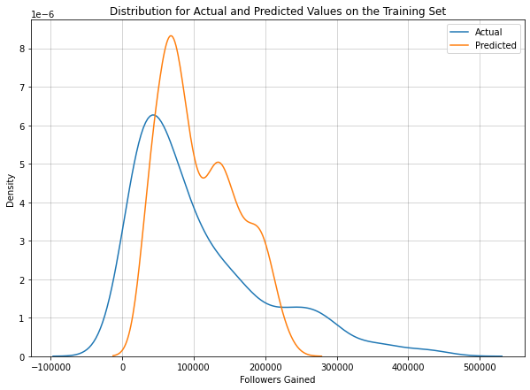

```python
# Predict followers gained using the random forest regression model on the training set
y_predicted = tuned_rf.best_estimator_.predict(X_train)

# Graph the distrabution of the actual training set data and our predicted data
fig, ax = plt.subplots(sharey = True, figsize=(10,7))
plt.title("Distribution for Actual and Predicted Values on the Training Set")
graph = sns.kdeplot(y_train, label = "Actual", ax = ax)
sns.kdeplot(y_predicted, label = "Predicted", ax = ax)
graph.set(xlabel = "Followers Gained", ylabel = "Density")
plt.grid(color = "black", alpha = 0.2)
plt.legend()
```

This graph depicts the distribution of Followers Gained from the training set portion of the dataset and the random forest regression algorithm run on the training set. We can see there is a sizable difference in predicted vs actual. The predicted distribution is more centered, it doesn't tail off as the actual dataset does. The predicted values are also higher for most of the distribution. What the prediction does well is capturing the skew towards the 0 - 100,000 range.

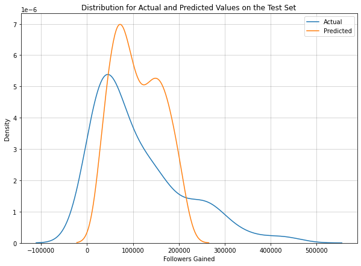

```python
# Predict followers gained using the random forest regression model on the test set
y_predicted = tuned_rf.best_estimator_.predict(X_test)

# Graph the distrabution of the actual test set data and our predicted data
fig, ax = plt.subplots(sharey = True, figsize=(10,7))
plt.title("Distribution for Actual and Predicted Values on the Test Set")
graph = sns.kdeplot(y_test, label = "Actual", ax = ax)
sns.kdeplot(y_predicted, label = "Predicted", ax = ax)
graph.set(xlabel = "Followers Gained", ylabel = "Density")
plt.grid(color = "black", alpha = 0.2)
plt.legend()
```

The distributions for the test set in actual and predicted are better but still inaccurate. The difference in the max of the predicted and actual above is lower than with the train set. but it keeps the same general form differences. The similarity in skew and shape shows the training and test set data were split well.

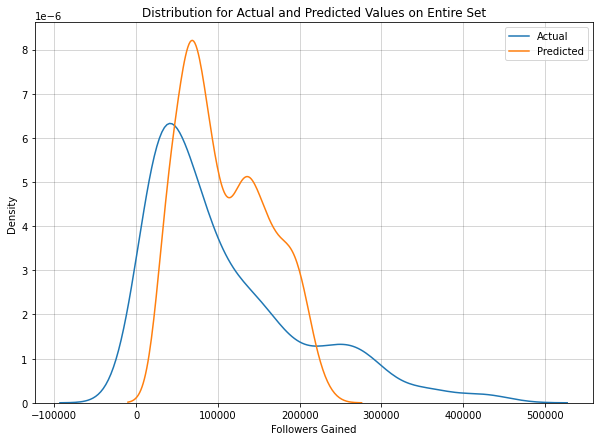

```python
# Predict followers gained using the random forest regression model
y_predicted = tuned_rf.best_estimator_.predict(X)

# Graph the distrabution of the actual data and our predicted data
fig, ax = plt.subplots(sharey = True, figsize=(10,7))
plt.title("Distribution for Actual and Predicted Values on Entire Set")
graph = sns.kdeplot(y, label = "Actual", ax = ax)
sns.kdeplot(y_predicted, label = "Predicted", ax = ax)
graph.set(xlabel = "Followers Gained", ylabel = "Density")
plt.grid(color = "black", alpha = 0.2)
plt.legend()
```

The last graph is the predicted and actual distributions of the entire dataset and the predictions of the random forest regression algorithm run on the entire dataset. We can see the issues present in the graphs above are still present here. The predicted values are more clumped toward the average and don't tail off. This shows that even with removing a large number of outliers, the data set was so spread out that local outliers became just as important when the larger ones are cut out.

## Conclusion

Despite trying multiple different regression algorithms and cutting out harmful data, we were never able to come up with an accurate model for predicting Twitch streamers' follower growth. We hypothesize this is due to there being external factors that affect follower growth that is not captured within the data set. An example of this is whether a channel has Twitch Drops enabled (viewers get free content for the game by watching the streamer), which would artificially inflate viewing numbers as people watch the stream for the in-game loot they would receive and not because they like the streamer. Machine learning is not perfect, the algorithms cannot create connections that don't exist. That is not to be discouraging, some variables won't be able to be predicted accurately, but it is a Data Scientist's job to explore the data and try to find the connections. Also, just because we weren't able to predict Follower growth with this dataset doesn't mean it can't be predicted in the future. To get a more accurate prediction, we could assemble a larger dataset that has more features than the one we were using. Regardless of the result, this tutorial has shown you the steps to clean, organize, plot, and apply machine learning algorithms to whatever projects you have in mind, hopefully with more success.